# Simple Linear Regression

Nassos Stylianou

23/10/2018

## Simple linear regression

Using the evals dataset from the `moderndive` package, we can look at the effect of age on the score students give a teacher.

Here’s what our data looks like

```r
library(moderndive)
library(dplyr)
glimpse(evals)
```

```
## Observations: 463
## Variables: 13
## $ ID           <int> 1, 2, 3, 4, 5, 6, 7, 8, 9, 10, 11, 12, 13, 14, 15...
## $ score        <dbl> 4.7, 4.1, 3.9, 4.8, 4.6, 4.3, 2.8, 4.1, 3.4, 4.5,...
## $ age          <int> 36, 36, 36, 36, 59, 59, 59, 51, 51, 40, 40, 40, 4...
## $ bty_avg      <dbl> 5.000, 5.000, 5.000, 5.000, 3.000, 3.000, 3.000, ...
## $ gender       <fct> female, female, female, female, male, male, male,...
## $ ethnicity    <fct> minority, minority, minority, minority, not minor...
## $ language     <fct> english, english, english, english, english, engl...
## $ rank         <fct> tenure track, tenure track, tenure track, tenure ...
## $ pic_outfit   <fct> not formal, not formal, not formal, not formal, n...
## $ pic_color    <fct> color, color, color, color, color, color, color, ...
## $ cls_did_eval <int> 24, 86, 76, 77, 17, 35, 39, 55, 111, 40, 24, 24, ...
## $ cls_students <int> 43, 125, 125, 123, 20, 40, 44, 55, 195, 46, 27, 2...
## $ cls_level    <fct> upper, upper, upper, upper, upper, upper, upper, ...
```

Plotting the distribution of age of teachers in our dataset.

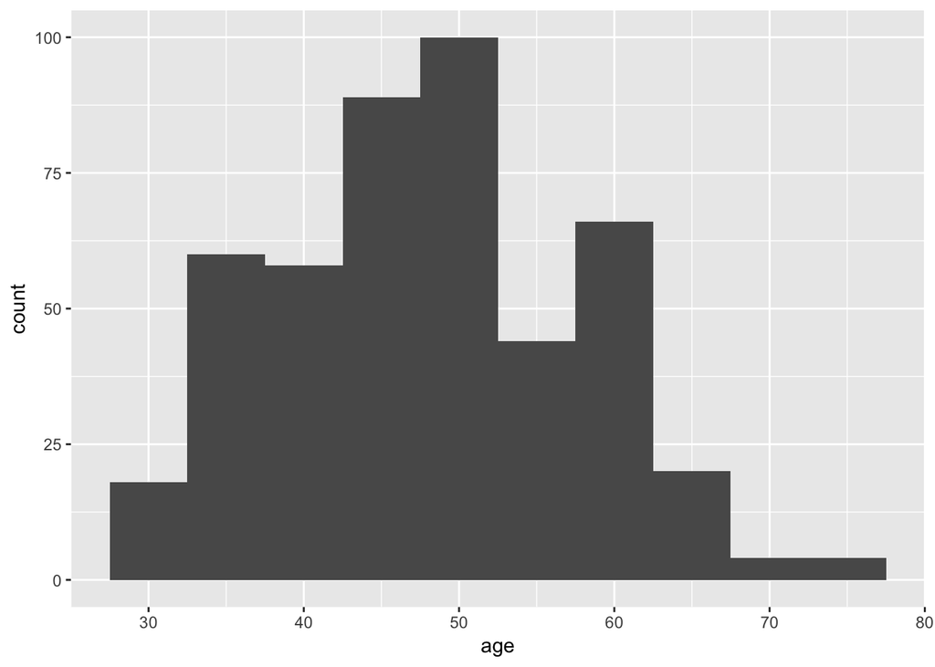

```r
library(ggplot2)
ggplot(evals, aes(x = age)) +
  geom_histogram(binwidth = 5) +
  labs(x = "age", y = "count")
```

Some summary statistics from the age column.

```r
evals %>%
  summarise(mean_age = mean(age),
            median_age = median(age),
            sd_age = sd(age))
```

```
## # A tibble: 1 x 3
##   mean_age median_age sd_age
##      <dbl>      <int>  <dbl>
## 1     48.4         48   9.80
```

## Plotting a best-fitting regression line

Plotting a best-fitting regression line (least squares) to examine the relationship between score (our outcome/dependent $y$ variable) and age (our explanatory/predictor $x$ variable).

In this case, we are running a regression with score as a function of the single explanatory/ predictor variable age.

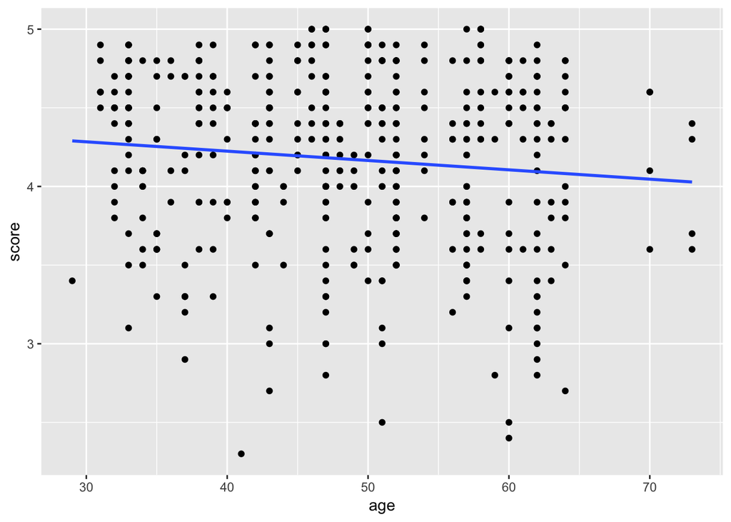

```r
ggplot(evals, aes(x = age, y = score)) +
  geom_point() +
  labs(x = "age", y = "score") +
  geom_smooth(method = "lm", se = FALSE)
```

The regression line shows a slight negative relationship between the two, as age increases, it looks like score goes down marginally.

To explicity quantify the linear relationship between score and age using linear regression, we first have to fit the model.

```r
model_score_age <- lm(score ~ age, data = evals)
model_score_age
```

```
##
## Call:
## lm(formula = score ~ age, data = evals)
##
## Coefficients:
## (Intercept)          age
##    4.461932    -0.005938
```

Once we hve fitted the model, we can use the `get_regression_table()` function of the `moderndive` package to get the regression table.

```r
get_regression_table(model_score_age)
```

```
## # A tibble: 2 x 7
##   term      estimate std_error statistic p_value lower_ci upper_ci
##   <chr>        <dbl>     <dbl>     <dbl>   <dbl>    <dbl>    <dbl>
## 1 intercept  4.46      0.127       35.2   0        4.21    4.71
## 2 age       -0.00600   0.00300    - 2.31  0.0210  -0.0110 -0.00100
```

## What does this mean?

If you look at the value for the slope of the line, it is -0.006. So For every increase of one in age, you should observe an associated decrease (as the figure is negative) of on average 0.006 units in teaching score.

## Predicting a teacher’s score just from their age

From the regression table and the intercept and slope, we can find the expected score based on their age. Say they are 44 years-old, the calculation we would have to do to get their score is:

```r
y_hat <- 4.462 + (-0.006 * 44)
y_hat
```

```
## [1] 4.198
```

If we found out that their score was 4.5, the residual for this prediction is the following:

```r
y <- 4.5
y - y_hat
```

```
## [1] 0.302
```

## Getting regression points

Say we want to repeat this for all 463 teachers, we can automate this using the `get_regression_points()` function from the `moderndive` package.

```r
get_regression_points(model_score_age) %>%
  head(10)
```

```
## # A tibble: 10 x 5
##       ID score   age score_hat residual
##    <int> <dbl> <dbl>     <dbl>    <dbl>
##  1     1  4.70  36.0      4.25   0.452
##  2     2  4.10  36.0      4.25  -0.148
##  3     3  3.90  36.0      4.25  -0.348
##  4     4  4.80  36.0      4.25   0.552
##  5     5  4.60  59.0      4.11   0.488
##  6     6  4.30  59.0      4.11   0.188
##  7     7  2.80  59.0      4.11  -1.31
##  8     8  4.10  51.0      4.16  -0.0590
##  9     9  3.40  51.0      4.16  -0.759
## 10    10  4.50  40.0      4.22   0.276
```

Here is how the contents of the score_hat column are actually being calculated:

```r
get_regression_points(model_score_age) %>%
  mutate(score_hat_manual = 4.462 + (-0.005938 * age)) %>%
  head(10)
```

```
## # A tibble: 10 x 6
##       ID score   age score_hat residual score_hat_manual
##    <int> <dbl> <dbl>     <dbl>    <dbl>            <dbl>
##  1     1  4.70  36.0      4.25   0.452              4.25
##  2     2  4.10  36.0      4.25  -0.148              4.25
##  3     3  3.90  36.0      4.25  -0.348              4.25
##  4     4  4.80  36.0      4.25   0.552              4.25
##  5     5  4.60  59.0      4.11   0.488              4.11
##  6     6  4.30  59.0      4.11   0.188              4.11
##  7     7  2.80  59.0      4.11  -1.31               4.11
##  8     8  4.10  51.0      4.16  -0.0590             4.16
##  9     9  3.40  51.0      4.16  -0.759              4.16
## 10    10  4.50  40.0      4.22   0.276              4.22
```

```r
get_regression_points(model_score_age) %>%
  mutate(residual_2 = score - score_hat)
```

```
## # A tibble: 463 x 6
##       ID score   age score_hat residual residual_2
##    <int> <dbl> <dbl>     <dbl>    <dbl>      <dbl>
##  1     1  4.70  36.0      4.25   0.452      0.452
##  2     2  4.10  36.0      4.25  -0.148     -0.148
##  3     3  3.90  36.0      4.25  -0.348     -0.348
##  4     4  4.80  36.0      4.25   0.552      0.552
##  5     5  4.60  59.0      4.11   0.488      0.488
##  6     6  4.30  59.0      4.11   0.188      0.188
##  7     7  2.80  59.0      4.11  -1.31      -1.31
##  8     8  4.10  51.0      4.16  -0.0590    -0.0590
##  9     9  3.40  51.0      4.16  -0.759     -0.759
## 10    10  4.50  40.0      4.22   0.276      0.276
## # ... with 453 more rows
```